# Barplots

## Introduction

After importing the kraken2 output files into R and processing them with phyloseq, it’s time to explore the taxonomic composition of our data. We will use the Polychrome package to create a custom palette for the barplots.

## Load necessary libraries.

```r
# install.packages(c("tidyverse","ggtext","Polychrome"))
library(phyloseq)
library(tidyverse)
library(Polychrome)
library(ggtext)
```

## Specifying parameters and directory/file names.

```r
source(here::here("config/R/config.R"))# config file with global variables
source(here::here("config/R/themes.R"))# config file with themes
```

The taxonomic rank that was used for agglomeration:

```r
agglom.rank <- "Species"
```

Import phyloseq object as an rds file (NOT rarefied):

```r
ps.q <- readRDS(file= ps.q.raw.fname)
ps.q.rel <-readRDS(file= ps.q.rel.raw.fname)
custom.md <- readRDS(custom.md.path)%>%
  filter(sequencing_type =="Naked mole-rat whole metagenome sequencing")

if(agglom.rank=="OTU" | agglom.rank=="Species"){
  ps.q.agg.rel<-ps.q.rel%>%
    psmelt()
  ps.q.agg <- ps.q%>%
    psmelt()
}else{
  ps.q.agg.rel<-ps.q.rel%>%
    tax_glom(taxrank = agglom.rank)%>%
    psmelt()%>%
    select(-OTU)
  ps.q.agg<-ps.q%>%
    tax_glom(taxrank = agglom.rank)%>%
    psmelt()%>%
    select(-OTU)
}
# Join the dataframe of relative abundances with absolute abundances
ps.q.agg <-  ps.q.agg.rel %>%
  rename("RelativeAbundance" = "Abundance")%>%
  left_join(ps.q.agg[,c("Sample",agglom.rank,"Abundance")])
mean_sd_relab.nmr_ages<- read.table(file.path(community.composition.tables,
                                               paste0("mean-max-min-sd-relab-nmr_ages-",agglom.rank,".tsv")),
                                    sep = "\t", header = T)
```

Check the total number of taxa (not filtered by mean relative abundance)

```r
ps.q.agg%>%
  ungroup()%>%
  select(matches(paste0("^",agglom.rank,"$")))%>%
  pull(.)%>%
  unique()%>%
  sort()%>%
  length()
```

```
## [1] 619
```

select(matches(paste0(“^”,agglom.rank,“$”))) will select variables that match a pattern (regex). So, if we are agglomerating by Phylum, the command will select the Phylum column

## Set up the barplot.

Find the column number that precedes Species (Genus column).

```r
if(agglom.rank=="Species"){
  agglom.rank.col<-which(colnames(ps.q.agg) =="Species")
  preceding.rank.col<-which(colnames(ps.q.agg) ==agglom.rank)-1
  preceding.rank<-colnames(ps.q.agg)[preceding.rank.col]
}else{
  agglom.rank.col<-which(colnames(ps.q.agg) ==agglom.rank)
  preceding.rank.col<-which(colnames(ps.q.agg) ==agglom.rank)-1
  preceding.rank<-colnames(ps.q.agg)[preceding.rank.col]
}
custom_order <- c("Kingdom", "Phylum", "Class", "Order", "Family","Genus","Species")
```

If we agglomerate by higher level (Order,Class, etc), need to adjust the rank

```r
if(agglom.rank%in%custom_order){
  agglom.rank.index<-match(agglom.rank,custom_order)
  custom_order<-custom_order[1:agglom.rank.index-1]
}
```

Find the average number of characters in the taxa to wrap long names:

```r
avg.taxon.len <- ps.q.agg%>%
  select(all_of(agglom.rank))%>%
  pull%>%
  nchar%>%
  mean%>%
  round
```

Hide rare taxa, wrap long names, highlight non-bacterial taxa.

```r
new.df<-ps.q.agg%>%
  unite("taxon",Kingdom:all_of(agglom.rank),sep = ";",remove = FALSE)%>%
  mutate(is_unclassified = grepl
         ("Kingdom|Phylum|Class|Order|Family|Genus|Species",taxon))%>% # add column to show that a taxon was unclassified
  left_join(mean_sd_relab.nmr_ages) %>%
  mutate(MeanRelativeAbundance = ifelse(is.na(MeanRelativeAbundance), 0, MeanRelativeAbundance))%>%
  mutate(is_unclassified=ifelse(is_unclassified==TRUE &!grepl
                                ("Kingdom|Phylum|Class|Order|Family|Genus|Species",
                                  get(agglom.rank)),
                                FALSE, is_unclassified))%>%
  mutate(
    taxon=ifelse(is_unclassified,
                      get(agglom.rank),
                      paste0(get(agglom.rank)#, " (",get(preceding.rank),
                             #")"
                             )),
    taxon = ifelse(mapply(grepl,get(preceding.rank),get(agglom.rank)),
                   taxon,
                   paste0(get(agglom.rank), " (", get(preceding.rank),")")),
    taxon=ifelse(MeanRelativeAbundance<1,
                 "Remainder (Mean relative abundance < 1%)",
                 taxon))%>% # if a taxon is classified, we change it to show the preceding rank, e.g Family (Genus)
  mutate(taxon=gsub("_"," ",taxon),
         taxon=str_wrap(taxon,width=avg.taxon.len))%>%
  mutate(taxon=ifelse(Kingdom=="Bacteria",
                      paste0("<span style='color: orange'><b><i>",taxon,"</i></b></span>"),
                      taxon),
         taxon=ifelse(Kingdom=="Eukaryota",
                      paste0("<span style='color: palegreen4'><b><i>",taxon,"</i></b></span>"),
                      taxon),
         taxon=ifelse(Kingdom=="Archaea",
                      paste0("<span style='color: violetred4'><b><i>",taxon,"</i></b></span>"),
                      taxon),
         taxon=ifelse(grepl("Remainder",taxon),
                      "Remainder (Mean relative abundance < 1%)",taxon))%>%
  group_by_at(c("is_unclassified",preceding.rank))%>%
  arrange(desc(is_unclassified),
          get(preceding.rank),
          taxon,
          .by_group = TRUE)%>% # sort within unclassified and classified taxa (by group)
  mutate(taxon=factor(taxon,levels=unique(taxon)),
         taxon=taxon%>%
           fct_relevel(c("Remainder (Mean relative abundance < 1%)",
                         unique(unlist(lapply(custom_order,
                                              function(pat){levels(.)[str_detect(levels(.),
                                                                                 fixed(pat))]
                                              })))
           ),
           after=0))%>% # change taxon column to factor. Then, we set "Remainder" as the first level, unclassified taxa next, then classified taxa. we use the str_detect to find unclassified taxa because these have Kingdom or Phylum in the name
  ungroup()
```

Create a color palette.  
We need to choose colors for the taxa in our barplot. They should be distinguishable, so we can’t choose similar colors. Or at least we shouldn’t put them next to each other.

We will use `createPalette` function from the `Polychrome` package. The function takes the number of colors for the palette and seed colors that will be used for palette generation. In this case, we use the number of rows in our legend (taxa) and rainbow colors (to avoid having similar colors next to each other). We also need to set the random seed because the output is a bit random. The output is a vector of colors.

```r
set.seed(1)
plot.cols<-createPalette(length(levels(unique(new.df$taxon))),
                         seedcolors =rainbow(7))# input: number of rows
```

Grey color is added ahead of others because it corresponds to Remainder taxa.

```r
plot.cols<-c("#C1CDCD",plot.cols[1:length(plot.cols)-1])
col.vec<-setNames(plot.cols,levels(new.df$taxon))
```

## Plot the barplot.

```r
mainplot <- new.df %>%
  left_join(custom.md[,c("Sample","age","host_birthday")])%>%
  arrange(age,host_birthday)%>%
  mutate(age = paste0("(",age,")"),
         age = factor(age),
         Sample = paste(Sample,age),
         Sample = factor(Sample,levels=unique(Sample)))%>%

  ggplot(aes(x=Sample,y=RelativeAbundance,fill=taxon))+
  geom_bar(stat="identity")+
  scale_fill_manual(values = col.vec) + # custom fill that is based on our custom palette
  coord_cartesian(expand=FALSE) +
  xlab("") +
  ylab("Relative Abundance (%)")+
  labs(fill="Taxon")+
  theme_bw() +
  guides(fill=guide_legend(ncol=1)) # legend as one column
```

Save the plot as an RDS object.

```r
saveRDS(mainplot,
        file = file.path(kraken2.manuscript.figures,
                         "kraken2.mainplot.rds"))

mainplot <- mainplot +
  theme(plot.margin=unit(c(0.4,0.4,0.4,1), 'cm'),
        strip.text.x = ggtext::element_markdown(size = 10),# the name of
        # each facet will be recognised as a markdown object, so we can
        # add line breaks (cause host names are too long)
        panel.spacing = unit(0.8, "cm"), # increase distance between facets
        axis.text.x = element_text(angle=45,size=13,hjust=1),# rotate
        # the x-axis labels by 45 degrees and shift to the right
        axis.text.y = element_text(size=13), # size of y axis ticks
        axis.title = element_text(size = 15), # size of axis names
        plot.title = element_text(size = 25), # size of plot title
        plot.caption = element_text(size=23), # size of plot caption
        legend.text = element_markdown(size = 13), # size of legend text
        legend.title = element_text(size = 17), # size of legend title
        legend.position = "right") # legend on the right
```

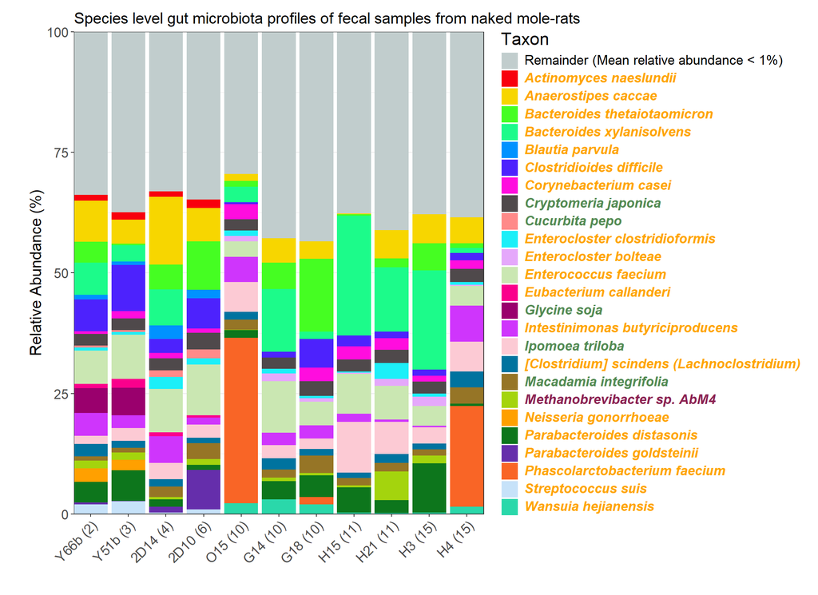

```r
print(mainplot+
        ggtitle(paste(agglom.rank,"level gut microbiota profiles of fecal samples from naked mole-rats"))+
        theme(plot.title = element_text(size=15))
)
```

```r
for(image.format in image.formats){
  ggsave(filename = paste0("kraken2-barplot-NMR.", image.format),
         path = community.composition.figures,
         plot=mainplot,
         width=11, height=7,units="in",
         dpi=300,device = image.format)
}
```

## Relative abundance per kingdom (including bacteria).

Read table with unclassified read numbers.

```r
unclassified_reads<-read.table(kraken2.unclassified.stats.fname,
                               header = T)
colnames(unclassified_reads)[which(colnames(unclassified_reads)=="Unclassified")]<-"Abundance"
unclassified_reads$Kingdom<-"Unclassified"

kingdom.plot.with_bact<-ps.q.agg%>%
  group_by(Sample,Kingdom)%>%
  summarise(Abundance=sum(Abundance))%>%
  bind_rows(unclassified_reads)%>%
  group_by(Kingdom)%>%
  summarise(TotalAbundance=sum(Abundance))%>%
  mutate(TotalAbundancePerTax=TotalAbundance/sum(TotalAbundance)*100)%>%
  arrange(-TotalAbundancePerTax)%>%
  ggplot(aes(x=reorder(Kingdom,-TotalAbundancePerTax),
             y=TotalAbundancePerTax,
             fill=Kingdom))+
  geom_bar(stat = "identity")+
  scale_fill_viridis_d(option = "C")+
  ylab("Relative abundance from all samples (%)")+
  xlab("")+
  theme_bw()
```

Save the plot as an RDS object.

```r
saveRDS(kingdom.plot.with_bact,
        file = file.path(kraken2.manuscript.figures,
                         "kraken2.kingdom.plot.with_bact.rds"))

kingdom.plot.with_bact <- kingdom.plot.with_bact +
  coord_cartesian(expand = c("bottom" = F,
                             "left" = F,
                             "right" = F)) +
  geom_text(aes(x=Kingdom,
                y=TotalAbundancePerTax,
                label=round(TotalAbundancePerTax,digits = 3)),
            vjust=-0.5,size = 5)+ # add text with percentage above the bar
  theme(axis.line = element_blank(),
        axis.text.x = element_text(size=13),
        axis.text.y = element_text(size=15), # size of y axis ticks
        axis.title = element_text(size = 15), # size of axis names
        plot.title = ggtext::element_markdown(size = 25), # the plot
        # title will be recognised as a markdown object, so we can
        # add line breaks (cause host names are too long)
        plot.caption = element_text(size=23),# size of plot caption
        legend.text = element_text(size = 13),# size of legend text
        legend.title = element_text(size = 17), # size of legend title
        legend.position = "none",
        panel.grid.minor = element_blank(),
        panel.grid.major = element_blank()) # no legend
```

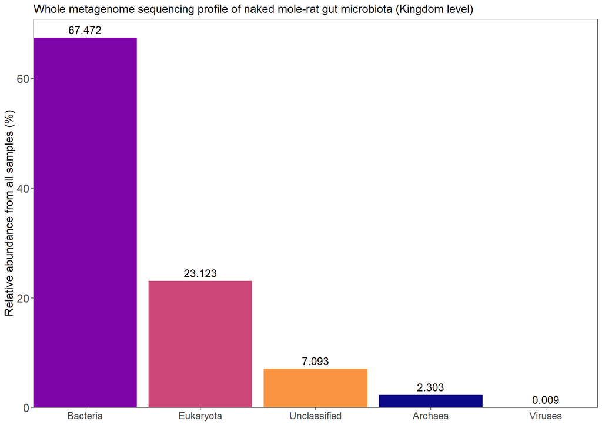

```r
print(kingdom.plot.with_bact+
        ggtitle("Whole metagenome sequencing profile of naked mole-rat gut microbiota
               (Kingdom level)")+
        theme(plot.title = ggtext::element_markdown(size=15))
)
```

```r
for(image.format in image.formats){
  ggsave(filename = paste0("NMR-kingdom.plot.with_unclas.", image.format),
         path = community.composition.figures,
         plot = kingdom.plot.with_bact,
         width=11, height=6,units="in",
         dpi=300,device = image.format)
}
```

Check library size per sample (not included)

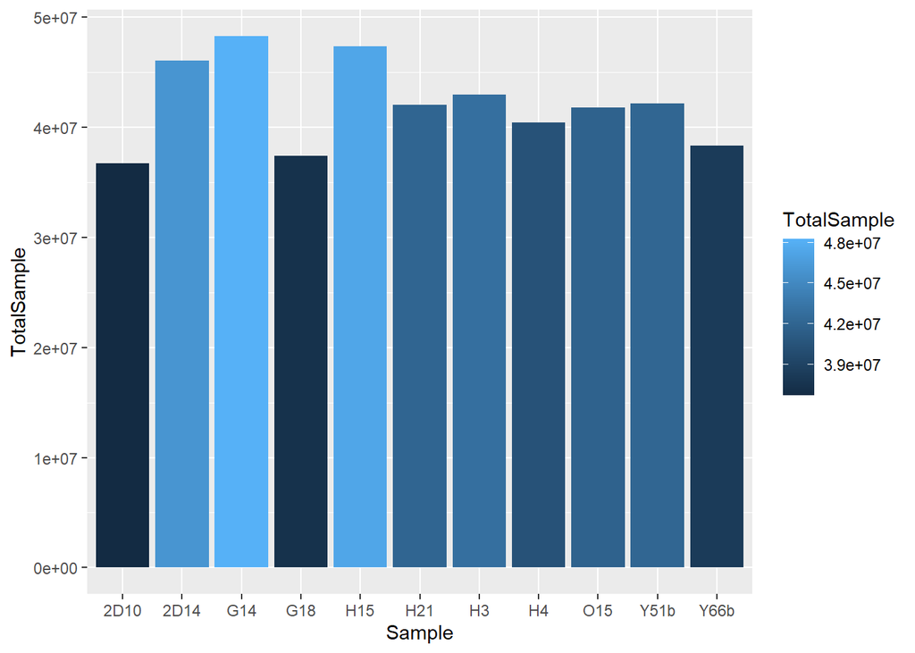

```r
ps.q.agg%>%
  group_by(Sample,Kingdom)%>%
  summarise(Abundance=sum(Abundance))%>%
  bind_rows(unclassified_reads)%>%
  group_by(Sample)%>%
  summarise(TotalSample=sum(Abundance))%>%
  ggplot(aes(x=Sample,y=TotalSample,fill=TotalSample))+
  geom_bar(stat = "identity")
```

```r
rm(list =setdiff(ls(all.names = TRUE), c("markdown.dir")))
gc()
```

```
##            used  (Mb) gc trigger  (Mb) max used  (Mb)
## Ncells  6846796 365.7   12516085 668.5 12516085 668.5
## Vcells 13385374 102.2   25846669 197.2 25846669 197.2
```